# Mutation by strain table

My goal here is to organize the breseq data in a t table with genes as rows and the strains as columns. Table cells will contain nubers indicating the nuber of mutations observed.

```r
rm(list=ls())
library(tidyverse, quietly = TRUE)
library(cowplot, quietly = TRUE)
library(viridis)
```

## Loading strain data

- trt: phage infection
- lim: limiting nutrient
- cID: chemostat number
- time: sampling time in days
- strain_ID: sample day + chemostat + strain number

```r
# table of strains and their source (time, treatment)
strains <- read_csv("../data/strains.csv")
# remove ansector
strains <- filter(strains,strain_ID!="WH7803")
strains
```

| trt | lim | cID | time | strain_ID |
| --- | --- | --- | --- | --- |
| Ph- | N | N2 | 1 | 01N2S3 |
| Ph- | N | N3 | 1 | 01N3S3 |
| Ph- | N | N5 | 1 | 01N5S4 |
| Ph- | P | P3 | 1 | 01P3S1 |
| Ph- | P | P4 | 1 | 01P4S5 |
| Ph- | P | P5 | 1 | 01P5S1 |
| Ph- | N | N1 | 3 | 03N1S1 |
| Ph+ | N | N2 | 3 | 03N2S5 |
| Ph+ | N | N3 | 3 | 03N3S2 |
| Ph+ | N | N3 | 3 | 03N3S4 |

[output cut: 26 more lines]

# Mutation data

I copy pasted the data found in *data/20140611_allcompare.html* into excel and cleaned it up a bit. Re-importing it preserved some of the charachters that were lost in the file as it is found in *data/breseq.compare.csv*.  
* I removed the first line that indicates a complete genome deletion. This results in strain 03N1S1 not having any mutation. this caused a bunch of NA being put in cells upon import, so I put in 0s instead.  
* I cleaned all the special charechters out of the mutation column. the right pointing arrow I replaced with “sub”, $\Delta$ was replaced by “d”, and a bunch of spces that acted funny upon import were changed to regular spaces.  
* Cleaning the anotation data from special charecters is too much of a mess. Instead I downloaded a table of the genetic features of WH7803 from ftp://ftp.ncbi.nlm.nih.gov/genomes/all/GCA/000/063/505/GCA_000063505.1_ASM6350v1/GCA_000063505.1_ASM6350v1_feature_table.txt.gz. I verified that the positions are similar to what is in the breseq html file in a few loci. seems like a perfect fit. This too required some cleanin to remove the duplicated rows and some empty columns.  
* replaced empty cells, “?”, $\Delta$ with “0”; replaced “100%” with 1.

```r
# Import data file
breseq <- read_csv("breseq_allcompare.csv")

# correct column names
colnames (breseq)<- gsub(".g","",colnames (breseq))
```

# Summarizing mutations by gene

```r
# # crop out the annotation data
# breseq.annot  <-
#   breseq%>%
#     select(position,mutation,annotation,gene,description)


#summarize mutations by gene
mXg <-
  breseq%>%
    select(-position,-mutation,-annotation)%>%
    group_by(gene, description)%>%
    summarize_if(is.numeric, sum, na.rm = TRUE)

mXg$gene <-  str_replace_all(mXg$gene, "[^[:alnum:],_,/]", "")
# write_csv(mXg, "mxg.csv")
knitr::kable(mXg)
```

| gene | description | 01N2S3 | 01N3S3 | 01N5S4 | 01P3S1 | 01P4S5 | 01P5S1 | 03N1S1 | 03N2S5 | 03N3S2 | 03N3S4 | 03N5S2 | 03P2S4 | 03P3S5 | 03P5S5 | 05N2S5 | 05N3S3 | 05P2S1 | 05P2S2 | 05P3S1 | 05P4S4 | 05P5S4 | 12P2S5 | 12P3S4 | 12P4S2 | 16N5S4 | 16P3S2 | 16P5S2 | 19N3S4 | … |
| --- | --- | --- | --- | --- | --- | --- | --- | --- | --- | --- | --- | --- | --- | --- | --- | --- | --- | --- | --- | --- | --- | --- | --- | --- | --- | --- | --- | --- | --- | --- |
| comB | 2‑phosphosulfolactate phosphatase | 0 | 0 | 0 | 0 | 0 | 0 | 0 | 0 | 0 | 0 | 0 | 0 | 0 | 0 | 0 | 0 | 0 | 0 | 1 | 0 | 0 | 0 | 0 | 0 | 0 | 0 | 0 | 0 | … |
| cpeS | phycoerythrin linker gene region | 0 | 0 | 0 | 0 | 0 | 0 | 0 | 0 | 0 | 0 | 0 | 0 | 0 | 1 | 0 | 0 | 0 | 0 | 0 | 0 | 0 | 0 | 0 | 0 | 0 | 0 | 0 | 0 | … |
| cpeY | bilin biosynthesis protein CpeY | 0 | 0 | 0 | 0 | 0 | 0 | 0 | 0 | 0 | 0 | 0 | 1 | 0 | 0 | 0 | 0 | 0 | 0 | 0 | 0 | 0 | 0 | 0 | 0 | 0 | 0 | 0 | 0 | … |
| ftsH | cell division protein FtsH | 0 | 0 | 0 | 0 | 0 | 0 | 0 | 0 | 0 | 0 | 0 | 0 | 0 | 0 | 0 | 0 | 0 | 0 | 0 | 1 | 0 | 0 | 0 | 0 | 0 | 0 | 0 | 0 | … |
| ftsY | Signal recognition particle GTPase, FtsY | 0 | 0 | 0 | 0 | 0 | 0 | 0 | 0 | 0 | 0 | 0 | 0 | 0 | 0 | 0 | 0 | 0 | 0 | 0 | 0 | 0 | 0 | 0 | 0 | 0 | 0 | 0 | 0 | … |
| fur | ferric uptake regulator family protein | 1 | 1 | 1 | 1 | 1 | 1 | 0 | 1 | 1 | 1 | 1 | 1 | 1 | 1 | 1 | 1 | 1 | 1 | 1 | 1 | 1 | 1 | 1 | 1 | 1 | 1 | 1 | 1 | … |
| ggt | gamma‑glutamyltranspeptidase | 0 | 0 | 0 | 0 | 0 | 0 | 0 | 0 | 0 | 0 | 0 | 0 | 0 | 0 | 0 | 0 | 0 | 0 | 0 | 0 | 0 | 0 | 0 | 0 | 0 | 0 | 0 | 0 | … |
| hupE | hydrogenase accessory membrane protein | 1 | 0 | 0 | 1 | 0 | 0 | 0 | 0 | 0 | 0 | 1 | 0 | 0 | 0 | 0 | 0 | 1 | 0 | 0 | 0 | 0 | 0 | 0 | 0 | 0 | 0 | 0 | 0 | … |
| ilvC | ketol‑acid reductoisomerase | 0 | 0 | 0 | 0 | 0 | 0 | 0 | 0 | 0 | 0 | 0 | 0 | 0 | 0 | 0 | 0 | 0 | 0 | 0 | 0 | 0 | 0 | 0 | 0 | 1 | 0 | 0 | 0 | … |
| miaA | tRNA delta(2)‑isopentenylpyrophosphate transferase | 0 | 0 | 0 | 0 | 0 | 0 | 0 | 0 | 0 | 0 | 1 | 0 | 0 | 0 | 0 | 0 | 0 | 0 | 0 | 0 | 0 | 0 | 0 | 0 | 0 | 0 | 0 | 0 | … |
| pebB | phycoerythrobilin:ferredoxin oxidoreductase | 0 | 0 | 0 | 0 | 0 | 0 | 0 | 0 | 0 | 0 | 0 | 0 | 0 | 0 | 0 | 0 | 0 | 0 | 0 | 0 | 0 | 0 | 0 | 0 | 0 | 0 | 0 | 0 | … |
| pntAA | NAD/NADP transhydrogenase subunit alpha part 1 | 0 | 0 | 0 | 0 | 0 | 0 | 0 | 0 | 0 | 0 | 0 | 0 | 0 | 0 | 0 | 0 | 0 | 0 | 1 | 0 | 0 | 0 | 0 | 0 | 0 | 0 | 0 | 0 | … |
| prlC | oligopeptidase A | 0 | 1 | 0 | 0 | 0 | 0 | 0 | 0 | 0 | 0 | 0 | 0 | 0 | 0 | 0 | 0 | 0 | 0 | 0 | 0 | 0 | 0 | 0 | 0 | 0 | 0 | 0 | 0 | … |
| psbA | photosystem II protein D1 | 0 | 0 | 0 | 0 | 0 | 0 | 0 | 0 | 0 | 0 | 0 | 0 | 0 | 0 | 0 | 0 | 0 | 0 | 0 | 0 | 0 | 0 | 0 | 0 | 0 | 0 | 0 | 0 | … |
| psbH | photosystem II reaction center protein H | 0 | 0 | 0 | 0 | 0 | 0 | 0 | 0 | 0 | 0 | 0 | 0 | 0 | 0 | 0 | 0 | 0 | 0 | 0 | 0 | 0 | 0 | 0 | 0 | 0 | 0 | 0 | 0 | … |
| pstA | phosphate ABC transporter permease | 0 | 0 | 0 | 0 | 0 | 0 | 0 | 0 | 0 | 0 | 0 | 0 | 0 | 0 | 0 | 0 | 0 | 0 | 0 | 0 | 0 | 0 | 0 | 0 | 0 | 0 | 0 | 0 | … |
| purE/nagA | phosphoribosylaminoimidazole carboxylase catalytic subunit/N‑acetylglucosamine‑6‑phosphate deacetylase | 0 | 0 | 0 | 0 | 0 | 0 | 0 | 0 | 0 | 1 | 0 | 0 | 0 | 0 | 0 | 0 | 0 | 0 | 0 | 0 | 0 | 0 | 0 | 0 | 0 | 0 | 0 | 0 | … |
| recC | exodeoxyribonuclease V subunit gamma | 0 | 0 | 0 | 0 | 0 | 0 | 0 | 0 | 0 | 1 | 0 | 0 | 0 | 0 | 0 | 0 | 0 | 0 | 0 | 0 | 0 | 0 | 0 | 0 | 0 | 0 | 0 | 0 | … |
| rfbC | dTDP‑4‑dehydrorhamnose 3,5‑epimerase | 0 | 0 | 0 | 0 | 0 | 0 | 0 | 0 | 0 | 0 | 0 | 0 | 0 | 0 | 0 | 0 | 0 | 0 | 0 | 0 | 0 | 0 | 0 | 0 | 0 | 0 | 0 | 0 | … |
| rfbD | putative dTDP‑4‑dehydrorhamnose reductase | 0 | 0 | 0 | 0 | 0 | 0 | 0 | 0 | 0 | 0 | 0 | 0 | 0 | 0 | 0 | 0 | 0 | 0 | 0 | 0 | 0 | 0 | 1 | 0 | 0 | 1 | 0 | 0 | … |
| RNA_16 | 16S ribosomal RNA | 0 | 0 | 2 | 3 | 0 | 2 | 0 | 0 | 0 | 0 | 0 | 0 | 0 | 0 | 0 | 2 | 0 | 0 | 1 | 3 | 1 | 2 | 2 | 0 | 0 | 0 | 0 | 2 | … |
| RNA_51 | 16S ribosomal RNA | 14 | 9 | 9 | 12 | 17 | 18 | 0 | 6 | 11 | 10 | 46 | 10 | 8 | 7 | 9 | 15 | 11 | 7 | 8 | 10 | 14 | 8 | 9 | 9 | 9 | 9 | 7 | 8 | … |
| SynWH7803_0099 | hypothetical protein | 0 | 0 | 0 | 0 | 0 | 0 | 0 | 0 | 0 | 0 | 0 | 0 | 0 | 0 | 0 | 0 | 0 | 0 | 0 | 0 | 0 | 0 | 0 | 0 | 0 | 0 | 0 | 0 | … |
| SynWH7803_0101/SynWH7803_0102 | hypothetical protein/glucose‑1‑phosphate thymidylyltransferase | 0 | 0 | 0 | 0 | 0 | 0 | 0 | 0 | 0 | 0 | 0 | 0 | 0 | 0 | 0 | 0 | 0 | 0 | 0 | 1 | 0 | 0 | 0 | 0 | 1 | 0 | 0 | 1 | … |
| SynWH7803_0102 | glucose‑1‑phosphate thymidylyltransferase | 0 | 0 | 0 | 0 | 0 | 0 | 0 | 0 | 0 | 0 | 0 | 0 | 0 | 1 | 0 | 1 | 0 | 0 | 0 | 0 | 0 | 0 | 1 | 0 | 0 | 0 | 0 | 0 | … |
| SynWH7803_0105 | sugar transferase | 0 | 0 | 0 | 0 | 0 | 0 | 0 | 0 | 0 | 0 | 1 | 0 | 0 | 0 | 0 | 0 | 1 | 0 | 0 | 0 | 0 | 0 | 0 | 0 | 0 | 0 | 0 | 0 | … |
| SynWH7803_0136 | ABC‑type polysaccharide/polyol phosphate transport system, ATPase component | 0 | 0 | 1 | 0 | 0 | 0 | 0 | 0 | 0 | 0 | 0 | 0 | 0 | 0 | 0 | 0 | 0 | 0 | 0 | 0 | 0 | 0 | 0 | 0 | 0 | 0 | 0 | 0 | … |
| SynWH7803_0139 | glycosyl transferase family protein | 0 | 1 | 0 | 0 | 0 | 0 | 0 | 0 | 0 | 0 | 0 | 0 | 0 | 0 | 0 | 0 | 0 | 0 | 0 | 0 | 0 | 0 | 0 | 0 | 0 | 0 | 0 | 0 | … |
| SynWH7803_0140 | glycosyl transferase family protein | 0 | 0 | 0 | 0 | 0 | 0 | 0 | 0 | 0 | 0 | 0 | 0 | 0 | 0 | 0 | 0 | 0 | 0 | 0 | 0 | 0 | 0 | 0 | 0 | 0 | 0 | 0 | 0 | … |
| SynWH7803_0191 | hypothetical protein | 0 | 0 | 1 | 0 | 0 | 0 | 0 | 0 | 0 | 0 | 0 | 0 | 0 | 0 | 0 | 0 | 0 | 0 | 0 | 0 | 0 | 0 | 0 | 0 | 0 | 0 | 0 | 0 | … |
| SynWH7803_0218 | glycosyl transferase family protein | 0 | 0 | 0 | 0 | 0 | 0 | 0 | 0 | 0 | 0 | 0 | 0 | 0 | 0 | 0 | 0 | 0 | 0 | 1 | 0 | 0 | 0 | 0 | 0 | 0 | 0 | 0 | 0 | … |
| SynWH7803_0219 | hypothetical protein | 0 | 0 | 0 | 0 | 0 | 0 | 0 | 0 | 1 | 1 | 0 | 0 | 0 | 0 | 0 | 0 | 0 | 0 | 0 | 0 | 0 | 0 | 1 | 0 | 1 | 0 | 0 | 1 | … |
| SynWH7803_0232 | hypothetical protein | 0 | 0 | 0 | 0 | 0 | 0 | 0 | 0 | 0 | 0 | 0 | 0 | 0 | 0 | 0 | 0 | 0 | 0 | 0 | 0 | 0 | 0 | 0 | 0 | 0 | 0 | 0 | 0 | … |
| SynWH7803_0260 | ABC transporter ATPase/permease | 0 | 0 | 0 | 0 | 0 | 0 | 0 | 0 | 0 | 0 | 0 | 1 | 0 | 0 | 0 | 0 | 0 | 0 | 0 | 0 | 0 | 0 | 0 | 0 | 0 | 0 | 0 | 0 | … |
| SynWH7803_0311 | alpha‑glucosidase | 0 | 0 | 0 | 0 | 0 | 0 | 0 | 0 | 0 | 0 | 0 | 0 | 0 | 0 | 0 | 0 | 0 | 0 | 0 | 1 | 0 | 0 | 0 | 0 | 0 | 0 | 0 | 0 | … |
| SynWH7803_0389/SynWH7803_0390 | hypothetical protein/hypothetical protein | 0 | 0 | 0 | 0 | 0 | 0 | 0 | 0 | 0 | 0 | 0 | 0 | 0 | 0 | 0 | 0 | 0 | 0 | 0 | 0 | 0 | 0 | 0 | 0 | 0 | 0 | 0 | 0 | … |
| SynWH7803_0438 | HAD family phosphatase | 0 | 1 | 0 | 0 | 0 | 0 | 0 | 0 | 0 | 0 | 0 | 0 | 0 | 0 | 0 | 0 | 0 | 0 | 0 | 0 | 0 | 0 | 0 | 0 | 0 | 0 | 0 | 0 | … |
| SynWH7803_0470 | oxidoreductase | 0 | 0 | 0 | 0 | 0 | 0 | 0 | 0 | 0 | 0 | 0 | 1 | 0 | 0 | 0 | 0 | 0 | 0 | 0 | 0 | 0 | 0 | 0 | 0 | 0 | 0 | 0 | 0 | … |
| SynWH7803_0483 | hypothetical protein | 0 | 0 | 1 | 0 | 0 | 0 | 0 | 0 | 0 | 0 | 0 | 0 | 0 | 0 | 0 | 0 | 0 | 0 | 0 | 0 | 0 | 0 | 0 | 0 | 0 | 0 | 0 | 0 | … |
| SynWH7803_0558 | hypothetical protein | 0 | 0 | 0 | 0 | 0 | 0 | 0 | 0 | 1 | 0 | 0 | 0 | 0 | 0 | 0 | 0 | 0 | 0 | 0 | 0 | 0 | 0 | 0 | 0 | 0 | 0 | 0 | 0 | … |
| SynWH7803_0562 | hypothetical protein | 0 | 0 | 0 | 0 | 0 | 0 | 0 | 0 | 0 | 0 | 0 | 0 | 0 | 0 | 0 | 0 | 1 | 0 | 0 | 0 | 0 | 0 | 0 | 0 | 0 | 0 | 0 | 0 | … |
| SynWH7803_0756 | glycogen branching protein | 1 | 1 | 1 | 1 | 1 | 1 | 0 | 1 | 1 | 1 | 1 | 1 | 1 | 1 | 1 | 1 | 1 | 1 | 1 | 1 | 1 | 1 | 1 | 1 | 1 | 1 | 1 | 1 | … |
| SynWH7803_0995/SynWH7803_0996 | hypothetical protein/hypothetical protein | 0 | 0 | 0 | 1 | 0 | 0 | 0 | 0 | 0 | 0 | 0 | 0 | 0 | 0 | 0 | 0 | 0 | 0 | 0 | 0 | 0 | 0 | 0 | 0 | 0 | 0 | 0 | 0 | … |
| SynWH7803_1018 | hypothetical protein | 0 | 0 | 0 | 0 | 0 | 0 | 0 | 0 | 0 | 0 | 0 | 0 | 0 | 0 | 0 | 0 | 0 | 0 | 0 | 0 | 0 | 0 | 0 | 0 | 0 | 0 | 0 | 0 | … |
| SynWH7803_1114 | kinase | 0 | 0 | 0 | 1 | 0 | 0 | 0 | 0 | 0 | 0 | 0 | 0 | 0 | 0 | 0 | 0 | 0 | 0 | 0 | 0 | 0 | 0 | 0 | 0 | 0 | 0 | 0 | 0 | … |
| SynWH7803_1161 | hypothetical protein | 0 | 0 | 0 | 1 | 0 | 0 | 0 | 0 | 0 | 0 | 0 | 0 | 0 | 0 | 0 | 0 | 0 | 0 | 0 | 0 | 0 | 0 | 0 | 0 | 0 | 0 | 0 | 0 | … |
| SynWH7803_1279 | hypothetical protein | 0 | 0 | 0 | 0 | 0 | 0 | 0 | 0 | 0 | 0 | 0 | 0 | 0 | 0 | 0 | 0 | 0 | 0 | 0 | 1 | 0 | 0 | 0 | 0 | 0 | 0 | 0 | 0 | … |
| SynWH7803_1381 | cation efflux family protein | 0 | 0 | 0 | 0 | 0 | 0 | 0 | 0 | 0 | 0 | 0 | 0 | 0 | 0 | 0 | 0 | 0 | 0 | 0 | 0 | 0 | 0 | 0 | 0 | 0 | 0 | 0 | 0 | … |
| SynWH7803_1386 | two‑component system sensor histidine kinase | 0 | 0 | 0 | 0 | 0 | 0 | 0 | 0 | 0 | 0 | 0 | 0 | 0 | 0 | 0 | 2 | 0 | 0 | 0 | 0 | 0 | 0 | 0 | 0 | 0 | 0 | 0 | 0 | … |
| SynWH7803_1446 | hypothetical protein | 0 | 0 | 0 | 0 | 0 | 0 | 0 | 0 | 0 | 0 | 0 | 0 | 0 | 0 | 0 | 0 | 0 | 0 | 0 | 0 | 0 | 0 | 0 | 0 | 0 | 0 | 0 | 0 | … |
| SynWH7803_1498/RNA_30 | hypothetical protein/tRNA‑Ser | 0 | 0 | 0 | 0 | 0 | 0 | 0 | 0 | 0 | 0 | 1 | 0 | 0 | 0 | 0 | 0 | 0 | 0 | 0 | 0 | 0 | 0 | 0 | 0 | 0 | 0 | 0 | 0 | … |
| SynWH7803_1711 | protein kinase | 0 | 0 | 0 | 0 | 1 | 0 | 0 | 0 | 0 | 0 | 0 | 0 | 0 | 0 | 0 | 0 | 0 | 0 | 0 | 0 | 0 | 0 | 0 | 0 | 0 | 0 | 0 | 0 | … |
| SynWH7803_1789 | hypothetical protein | 0 | 0 | 0 | 0 | 0 | 0 | 0 | 0 | 0 | 0 | 0 | 0 | 0 | 0 | 0 | 0 | 0 | 0 | 0 | 0 | 0 | 0 | 0 | 0 | 0 | 0 | 0 | 0 | … |
| SynWH7803_1859 | glycosyltransferase family protein | 0 | 0 | 0 | 0 | 0 | 0 | 0 | 0 | 0 | 0 | 1 | 0 | 0 | 0 | 0 | 0 | 0 | 0 | 0 | 0 | 0 | 0 | 0 | 0 | 0 | 0 | 0 | 0 | … |
| SynWH7803_1882 | hypothetical protein | 0 | 0 | 0 | 0 | 0 | 0 | 0 | 0 | 0 | 0 | 1 | 0 | 0 | 0 | 0 | 0 | 0 | 0 | 0 | 0 | 0 | 0 | 0 | 0 | 0 | 0 | 0 | 0 | … |
| SynWH7803_1923 | hypothetical protein | 0 | 0 | 1 | 0 | 0 | 0 | 0 | 0 | 0 | 0 | 0 | 0 | 0 | 0 | 0 | 0 | 0 | 0 | 0 | 0 | 0 | 0 | 0 | 0 | 0 | 0 | 0 | 0 | … |
| SynWH7803_2093 | hypothetical protein | 0 | 0 | 0 | 0 | 0 | 0 | 0 | 0 | 0 | 0 | 0 | 0 | 0 | 0 | 0 | 0 | 0 | 0 | 0 | 0 | 0 | 0 | 0 | 0 | 0 | 0 | 0 | 0 | … |
| SynWH7803_2122 | hypothetical protein | 0 | 0 | 0 | 0 | 0 | 1 | 0 | 0 | 0 | 0 | 0 | 0 | 0 | 0 | 0 | 0 | 0 | 0 | 0 | 0 | 0 | 0 | 0 | 0 | 0 | 0 | 0 | 0 | … |
| SynWH7803_2208 | Fe‑S oxidoreductase | 0 | 0 | 0 | 0 | 0 | 0 | 0 | 0 | 0 | 0 | 0 | 0 | 1 | 0 | 0 | 0 | 0 | 0 | 0 | 1 | 0 | 0 | 0 | 0 | 0 | 0 | 0 | 0 | … |
| SynWH7803_2230 | Na+/H+ antiporter | 0 | 0 | 0 | 0 | 0 | 0 | 0 | 0 | 0 | 0 | 0 | 0 | 0 | 0 | 0 | 1 | 0 | 0 | 0 | 0 | 0 | 0 | 0 | 0 | 0 | 0 | 0 | 0 | … |
| SynWH7803_2290 | NADH dehydrogenase subunit I | 0 | 0 | 0 | 0 | 0 | 0 | 0 | 0 | 0 | 0 | 0 | 0 | 0 | 0 | 0 | 0 | 0 | 0 | 0 | 0 | 0 | 0 | 1 | 0 | 0 | 0 | 0 | 0 | … |
| SynWH7803_2307 | hypothetical protein | 0 | 1 | 0 | 0 | 0 | 0 | 0 | 0 | 0 | 0 | 0 | 0 | 0 | 0 | 0 | 0 | 0 | 0 | 0 | 0 | 0 | 0 | 0 | 0 | 0 | 0 | 0 | 0 | … |
| SynWH7803_2345 | carbohydrate‑binding protein | 0 | 0 | 0 | 0 | 0 | 1 | 0 | 0 | 0 | 0 | 0 | 0 | 0 | 0 | 0 | 0 | 0 | 0 | 0 | 0 | 0 | 0 | 0 | 0 | 0 | 0 | 0 | 0 | … |
| SynWH7803_2356 | hypothetical protein | 0 | 1 | 0 | 0 | 1 | 1 | 0 | 0 | 1 | 0 | 0 | 1 | 0 | 1 | 0 | 1 | 0 | 0 | 1 | 0 | 0 | 0 | 1 | 0 | 1 | 0 | 0 | 1 | … |
| SynWH7803_2402 | hypothetical protein | 1 | 1 | 1 | 1 | 1 | 1 | 0 | 1 | 1 | 1 | 1 | 1 | 1 | 1 | 1 | 1 | 1 | 1 | 1 | 1 | 1 | 1 | 1 | 1 | 1 | 1 | 1 | 1 | … |
| tatD | Mg‑dependent DNase | 0 | 0 | 0 | 0 | 0 | 0 | 0 | 0 | 0 | 0 | 0 | 0 | 0 | 0 | 0 | 0 | 0 | 0 | 0 | 0 | 0 | 0 | 1 | 0 | 0 | 0 | 0 | 0 | … |
| uppS | undecaprenyl pyrophosphate synthase | 0 | 0 | 0 | 0 | 0 | 0 | 0 | 0 | 0 | 0 | 0 | 0 | 0 | 0 | 0 | 0 | 0 | 0 | 1 | 0 | 0 | 0 | 0 | 0 | 0 | 0 | 0 | 0 | … |
| uup | ABC transporter ATPase | 0 | 0 | 0 | 0 | 0 | 0 | 0 | 0 | 0 | 0 | 0 | 0 | 1 | 0 | 0 | 0 | 0 | 0 | 0 | 0 | 0 | 0 | 0 | 0 | 0 | 0 | 0 | 0 | … |
| xylB | xylulose kinase | 0 | 0 | 0 | 0 | 0 | 0 | 0 | 0 | 0 | 0 | 0 | 0 | 0 | 0 | 0 | 0 | 0 | 0 | 0 | 0 | 0 | 0 | 0 | 0 | 0 | 0 | 0 | 1 | … |

## summarize by treatment

Consolidate columns (strains) that have the come from the same treaatment (nutrient and phage)

```r
# test for compatability between strain and mutation tables

# strain names from mutation data
breseq.strains <-
  breseq%>%
  select_if(is.numeric)%>%
  select(-position)%>%
  colnames()

# sum(!(breseq.strains %in% strains$strain_ID)) #0
# sum(!(strains$strain_ID %in% breseq.strains)) #0
# # the lists match!
trtXg <-
#transpose the table
mXg %>%
  select(-description)%>%
  pivot_longer( cols = c(2:ncol(.)),names_to = "strain_ID", values_to = "mutations")%>%
  pivot_wider(id_cols = strain_ID, names_from = "gene", values_from = "mutations")%>%
  # add the meta data
  left_join(select(strains,trt, lim, strain_ID), . )%>%
  #summarize treatments
  group_by(trt, lim)%>%
  mutate(n.strains=n())%>%
  group_by(trt, lim,n.strains)%>%
  summarize_if(is_double, sum, na.rm = TRUE)%>%
  # transpose back
  mutate(meta=paste0(lim,".",trt,".","n", n.strains))%>%
  ungroup()%>%
  select(-trt, -lim, -n.strains)%>%
  pivot_longer( cols = c(1:(ncol(.)-1)),names_to = "gene", values_to = "mutations")%>%
  pivot_wider(id_cols = gene, names_from = "meta", values_from = "mutations")
trtXg
```

| gene | N.Ph-.n4 | P.Ph-.n9 | N.Ph+.n10 | P.Ph+.n13 |
| --- | --- | --- | --- | --- |
| comB | 0 | 1 | 0 | 0 |
| cpeS | 0 | 0 | 0 | 1 |
| cpeY | 0 | 0 | 0 | 1 |
| ftsH | 0 | 0 | 0 | 2 |
| ftsY | 0 | 1 | 0 | 0 |
| fur | 3 | 9 | 10 | 13 |
| ggt | 0 | 0 | 0 | 1 |
| hupE | 1 | 1 | 1 | 1 |
| ilvC | 0 | 0 | 1 | 0 |
| miaA | 0 | 0 | 1 | 0 |

[output cut: 59 more lines]

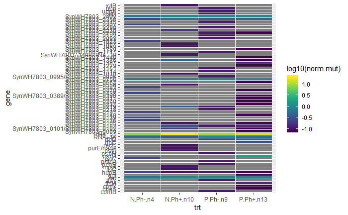

```r
#To normalize mutations I want number of strains
n.strains <-
  mXg %>%
    select(-description)%>%
    pivot_longer( cols = c(2:ncol(.)),names_to = "strain_ID", values_to = "mutations")%>%
    pivot_wider(id_cols = strain_ID, names_from = "gene", values_from = "mutations")%>%
    # add the meta data
    left_join(select(strains,trt, lim, strain_ID), . )%>%
    #summarize treatments
    group_by(trt, lim)%>%
    mutate(n=n())%>%
    select(trt,lim,n)%>%
    group_by(trt, lim,n)%>%
    summarise()
#normalize
trtXg%>%
  select(-gene)%>%
  sweep(., 2,FUN="/",STATS=n.strains$n)%>%
  #add gene names back
  mutate(gene=trtXg$gene)%>%
  #prepare for plotting
  pivot_longer(cols = colnames(trtXg)[-1], names_to = "trt", values_to = "norm.mut")%>%
  ggplot(aes(x=trt, y=gene,fill=log10(norm.mut)))+
  geom_tile(colour="white",size=0.25)+
  scale_fill_viridis()->p

# ggsave("heatmap.pdf",p, height = 10)

p
```

```r
NA
NA
```

# Consolidate mutations by chemostat

We need to account for repeated samples from the same chemostat and normalize for different number of chemstats per treamtent combination.

## chemostats per treatment

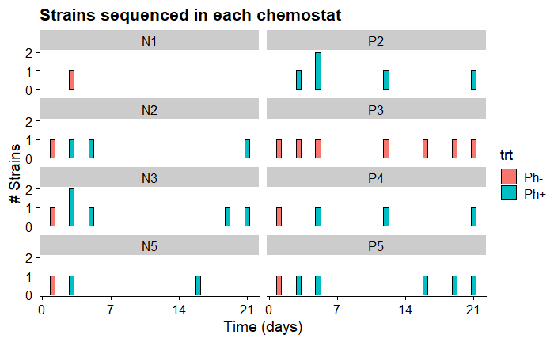

```r
strains%>%
  ggplot(aes(x=time))+
  geom_bar(aes(fill=trt), color="black", width=0.5)+
  facet_wrap(~cID, ncol = 2, dir = "v")+
  theme_cowplot()+
  scale_y_continuous(breaks = c(0,1,2))+
  scale_x_continuous(breaks=seq(0,21,7))+
  ggtitle("Strains sequenced in each chemostat")+
  xlab("Time (days)")+
  ylab("# Strains")
```

I think we will need to treat the no-phage sample of each chemostat as that chemostat’s ancestor.

## presence-absence of mutations by chemostat.

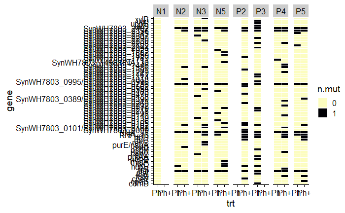

## numbers to normalize to

i.e. what is the number of independent observations